# Bike Sharing Demand - Solution

www.PredictiveInsightsAI.com Solution to SOA PA 6/18/20

02 April, 2021

```r
#NO CHANGES NEEDED
# Load needed libraries.
library(ggplot2)
library(dplyr)
library(tidyr)
library(caret)
library(kableExtra) #If needed, install this package.  It's just used for making tables.
library(ExamPAData)

theme_set(theme_minimal())

#function to create html tables
make_table <- function(df, caption = ""){
  df %>%
    kable(caption = caption) %>%
    kable_styling(bootstrap_options = "striped", full_width = F)}

#global chunk options
knitr::opts_chunk$set(warning = F, message = F, echo = T, fig.width = 14, fig.height = 8)
```

# Task 1 - Select factor variables.

```r
# Task 1 Select which variables will be treated as factor variables.

# Load packages
library(tidyverse)

# Load the data
data.all <- read.csv("December 7 data.csv")

glimpse(data.all)
```

```
## Rows: 17,376
## Columns: 10
## $ season         <int> 1, 1, 1, 1, 1, 1, 1, 1, 1, 1, 1, 1, 1, 1, 1, 1, 1, 1...
## $ year           <int> 0, 0, 0, 0, 0, 0, 0, 0, 0, 0, 0, 0, 0, 0, 0, 0, 0, 0...
## $ hour           <int> 0, 1, 2, 3, 4, 5, 6, 7, 8, 9, 10, 11, 12, 13, 14, 15...
## $ holiday        <int> 0, 0, 0, 0, 0, 0, 0, 0, 0, 0, 0, 0, 0, 0, 0, 0, 0, 0...
## $ weekday        <int> 6, 6, 6, 6, 6, 6, 6, 6, 6, 6, 6, 6, 6, 6, 6, 6, 6, 6...
## $ weathersit     <int> 1, 1, 1, 1, 1, 2, 1, 1, 1, 1, 1, 1, 1, 2, 2, 2, 2, 2...
## $ temp           <dbl> 0.24, 0.22, 0.22, 0.24, 0.24, 0.24, 0.22, 0.20, 0.24...
## $ humidity       <dbl> 0.81, 0.80, 0.80, 0.75, 0.75, 0.75, 0.80, 0.86, 0.75...
## $ windspeed      <dbl> 0.0000, 0.0000, 0.0000, 0.0000, 0.0000, 0.0896, 0.00...
## $ bikes_per_hour <int> 16, 40, 32, 13, 1, 1, 2, 3, 8, 14, 36, 56, 84, 94, 1...
```

```r
# Change data type to factor variables as needed
# Replace VARIABLE with the variable name twice. Copy and paste as needed.
data.all$season <- as.factor(data.all$season)
data.all$holiday <- as.factor(data.all$holiday)
data.all$weekday <- as.factor(data.all$weekday)
data.all$weathersit <- as.factor(data.all$weathersit)
data.all$year <- as.factor(data.all$year)

# Rename factor variable level names with descriptive names as needed
# Replace VARIABLE with the variable name once and LEVEL with the level names two or more times. The order should match that given when executing levels(data.all$VARIABLE). Copy and paste as needed.
levels(data.all$holiday) <- c("not_holiday", "holiday")
levels(data.all$weekday) <- c("Sun", "Mon", "Tue", "Wed", "Thu", "Fri", "Sat")
levels(data.all$weathersit) <- c("Clear or cloudy", "Mist", "Snow r rain")
levels(data.all$year) <- c("2011", "2012")

# Relevel the factor variables
# Replace VARIABLE names with a list of factor variables to relevel as needed. Add variable names as needed.
vars <- c("holiday", "weekday", "weathersit", "season", "year")

for (i in vars) {
  table <- as.data.frame(table(data.all[, i]))
  max <- which.max(table[, 2])
  level.name <- as.character(table[max, 1])
  data.all[, i] <- relevel(data.all[, i], ref = level.name)
}
rm(i, max, table, level.name, vars)

# Summarize the data
summary(data.all)
```

```
##  season     year           hour              holiday      weekday
##  3:4496   2012:8732   Min.   : 0.00   not_holiday:16876   Sat:2511
##  1:4239   2011:8644   1st Qu.: 6.00   holiday    :  500   Sun:2502
##  2:4409               Median :12.00                       Mon:2478
##  4:4232               Mean   :11.55                       Tue:2453
##                       3rd Qu.:18.00                       Wed:2474
##                       Max.   :23.00                       Thu:2471
##                                                           Fri:2487
##            weathersit         temp          humidity        windspeed
##  Clear or cloudy:11413   Min.   :0.020   Min.   :0.0000   Min.   :0.0000
##  Mist           : 4544   1st Qu.:0.340   1st Qu.:0.4800   1st Qu.:0.1045
##  Snow r rain    : 1419   Median :0.500   Median :0.6300   Median :0.1940
##                          Mean   :0.497   Mean   :0.6272   Mean   :0.1901
##                          3rd Qu.:0.660   3rd Qu.:0.7800   3rd Qu.:0.2537
##                          Max.   :1.000   Max.   :1.0000   Max.   :0.8507
##
##  bikes_per_hour
##  Min.   :  1.0
##  1st Qu.: 40.0
##  Median :142.0
##  Mean   :189.5
##  3rd Qu.:281.0
##  Max.   :977.0
##
```

# Task 2 - Consider a new variable.

No additional code provided.

# Task 3 - Write an overview of the data for your actuarial manager.

> The following set of Rmd code snippets may be useful in your data exploration. Include your own work here and then remove or comment out the unused templates.

```r
# Means and medians of the target variable split by predictor variables.
library(ggplot2)
# Replace VARIABLE names with a list of factor variables as needed. Add variable names as needed.
vars <- c("weekday", "holiday", "season")
for (i in vars) {
  x <- data.all %>%
    group_by_(i) %>%
    summarise(
      mean = mean(bikes_per_hour),
      median = median(bikes_per_hour),
      n = n()
    )

  print(x)
}
```

```
## # A tibble: 7 x 4
##   weekday  mean median     n
## * <fct>   <dbl>  <dbl> <int>
## 1 Sat      190.   129   2511
## 2 Sun      177.   116   2502
## 3 Mon      184.   138.  2478
## 4 Tue      191.   147   2453
## 5 Wed      191.   144.  2474
## 6 Thu      196.   154   2471
## 7 Fri      196.   165   2487
## # A tibble: 2 x 4
##   holiday      mean median     n
## * <fct>       <dbl>  <dbl> <int>
## 1 not_holiday  190.    144 16876
## 2 holiday      157.     97   500
## # A tibble: 4 x 4
##   season  mean median     n
## * <fct>  <dbl>  <dbl> <int>
## 1 3       236.   199   4496
## 2 1       111.    76   4239
## 3 2       208.   165   4409
## 4 4       199.   156.  4232
```

```r
rm(i, x, vars)
```

```r
# Correlation matrix for numeric variables
cor.matrix <- cor(data.all[, sapply(data.all, is.numeric)])
print("Correlation Matrix")
```

```
## [1] "Correlation Matrix"
```

```r
cor.matrix
```

```
##                      hour        temp    humidity   windspeed bikes_per_hour
## hour            1.0000000  0.13762245 -0.27658641  0.13727857     0.39408869
## temp            0.1376224  1.00000000 -0.06954217 -0.02310773     0.40470206
## humidity       -0.2765864 -0.06954217  1.00000000 -0.29021337    -0.32282543
## windspeed       0.1372786 -0.02310773 -0.29021337  1.00000000     0.09329335
## bikes_per_hour  0.3940887  0.40470206 -0.32282543  0.09329335     1.00000000
```

```r
rm(cor.matrix)
```

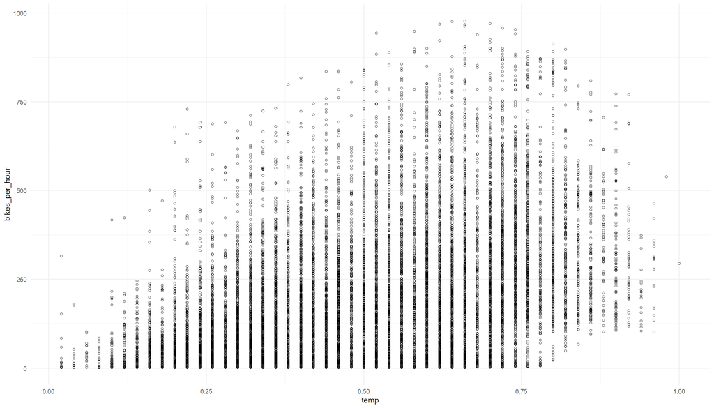

```r
# Scatter plots for numeric variables
# Replace VARIABLE names as needed, with color being optional.
ggplot(data.all, aes(x = temp, y = bikes_per_hour)) +
  geom_point(shape = 1)
```

```r
summary(data.all$temp)
```

```
##    Min. 1st Qu.  Median    Mean 3rd Qu.    Max.
##   0.020   0.340   0.500   0.497   0.660   1.000
```

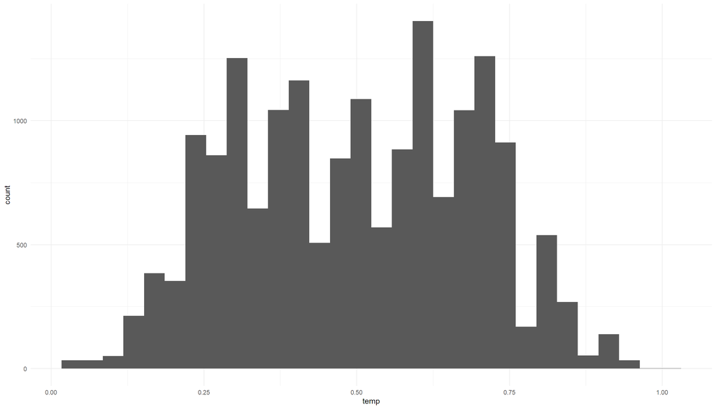

```r
data.all %>%
  ggplot(aes(temp)) +
  geom_histogram()
```

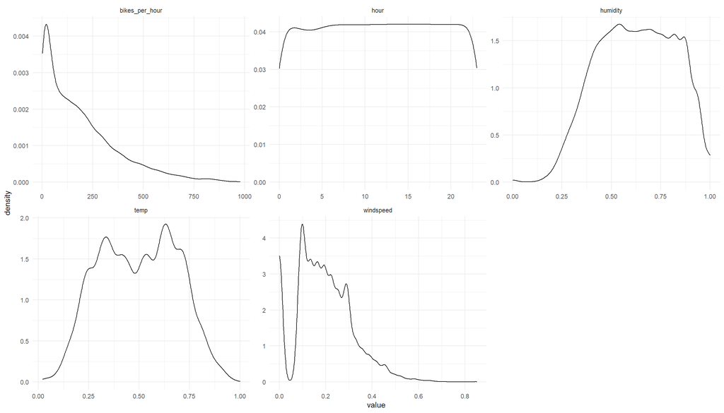

```r
# Density charts for numeric variables
data.all %>%
  select_if(is.numeric) %>%
  gather() %>% # Make key value pairs that allows the use of facet_wrap
  ggplot(aes(value)) +
  facet_wrap(~key, scales = "free") +
  geom_density()
```

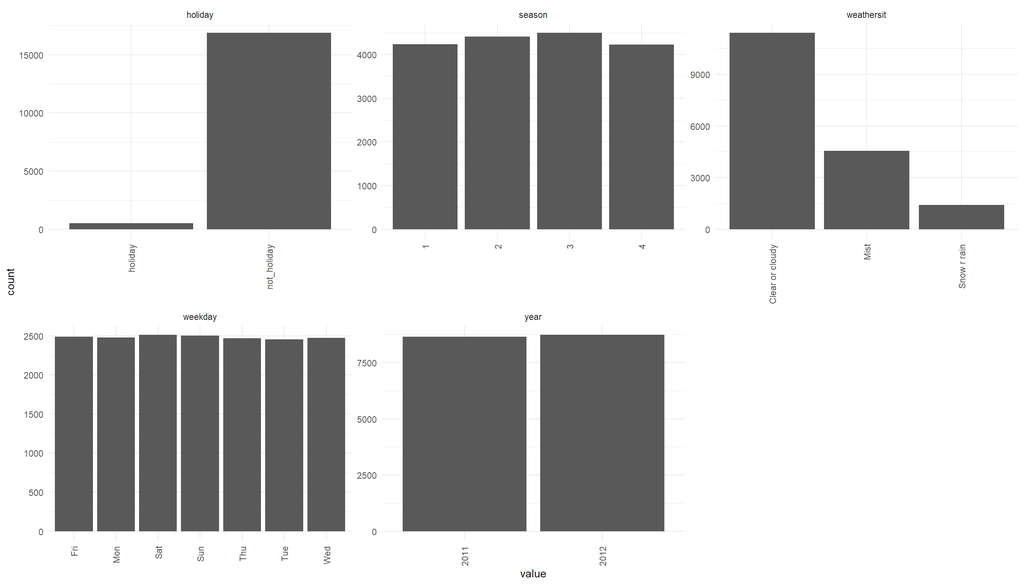

```r
# Bar charts for factor variables
data.all %>%
  select_if(is.factor) %>%
  gather() %>%
  ggplot(aes(value)) +
  facet_wrap(~key, scales = "free") +
  geom_bar() +
  theme(axis.text.x = element_text(angle = 90, hjust = 1, vjust = 0.5))
```

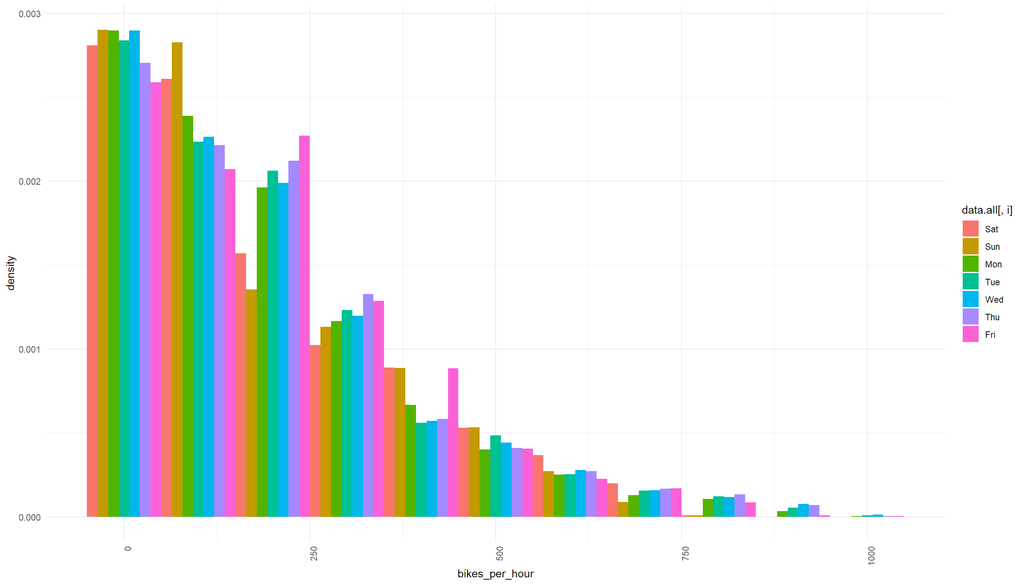

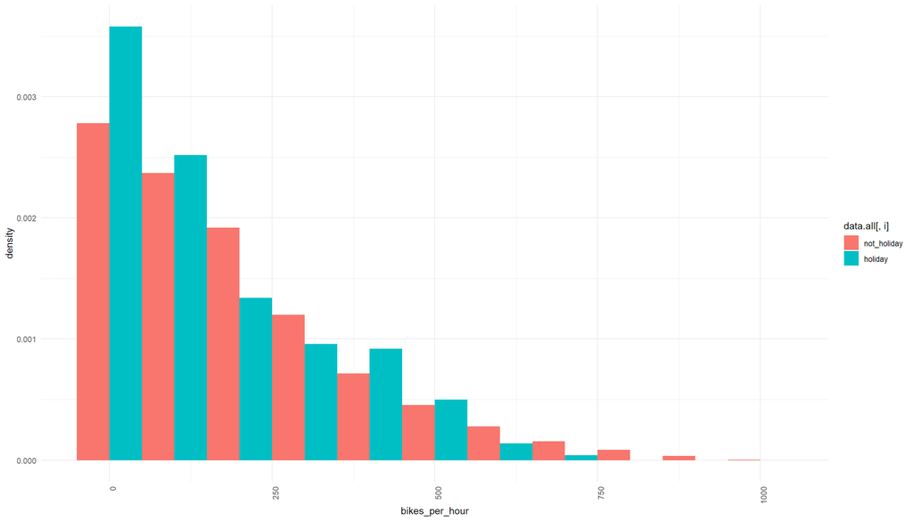

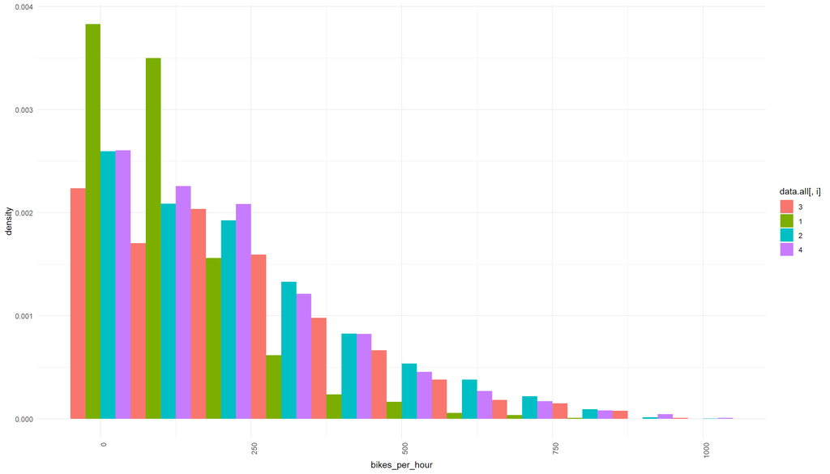

```r
# Split histograms for factor variables
# Replace VARIABLE names with a list of factor variables as needed. Add variable names as needed.
vars <- c("weekday", "holiday", "season")
for (i in vars) {
  plot <- ggplot(data.all, aes(
    x = bikes_per_hour,
    group = data.all[, i],
    fill = data.all[, i],
    y = ..density..
  )) +
    geom_histogram(position = "dodge", binwidth = 100) +
    theme(axis.text.x = element_text(angle = 90, hjust = 1))

  print(plot)
}
```

```r
rm(i, plot, vars)
```

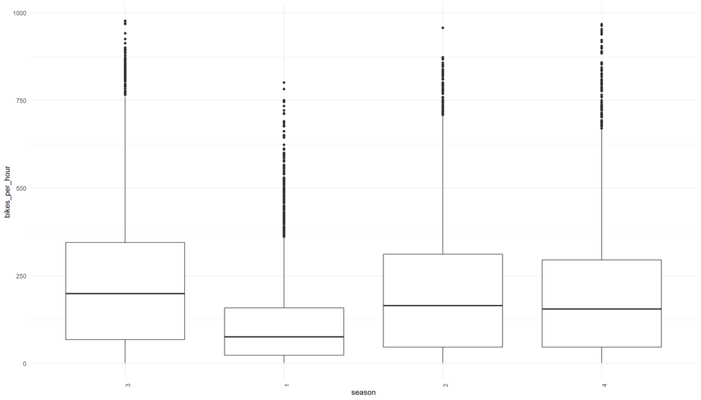

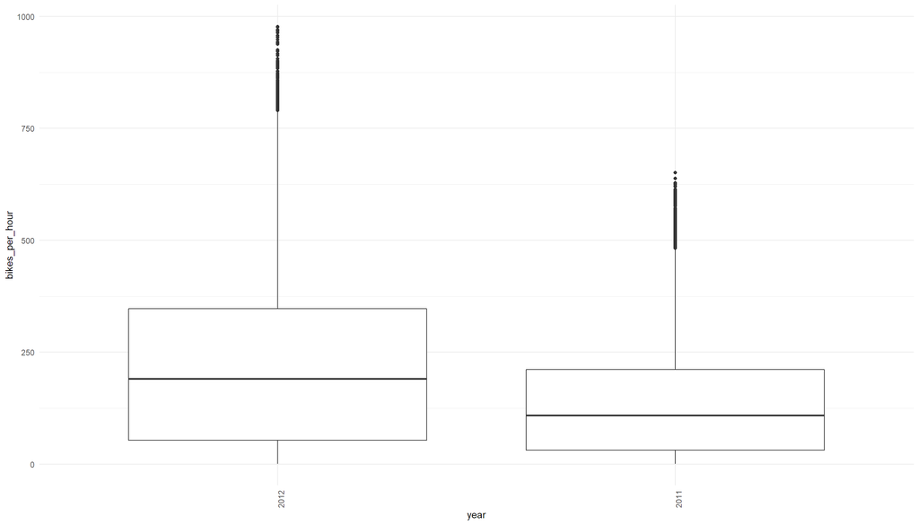

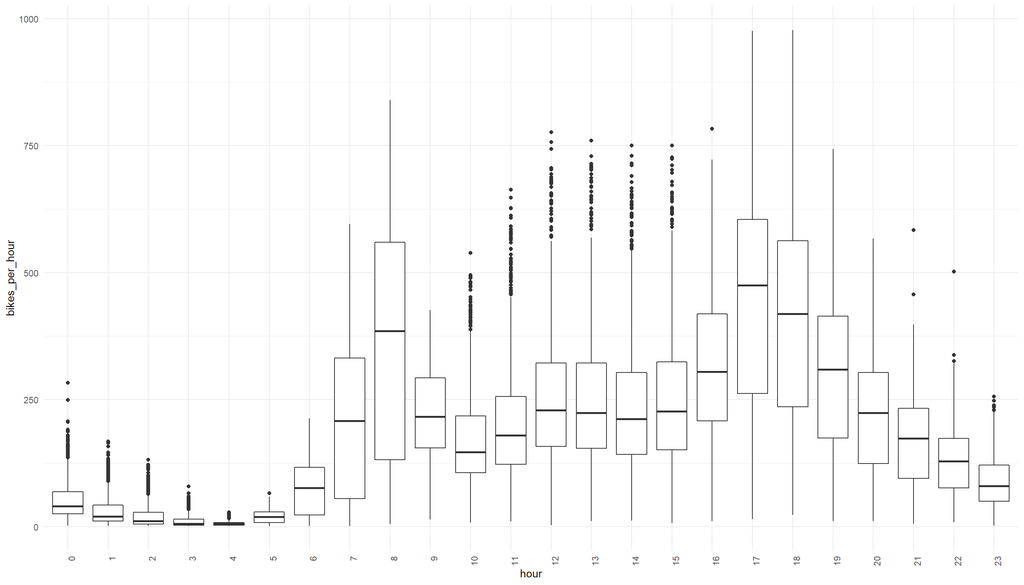

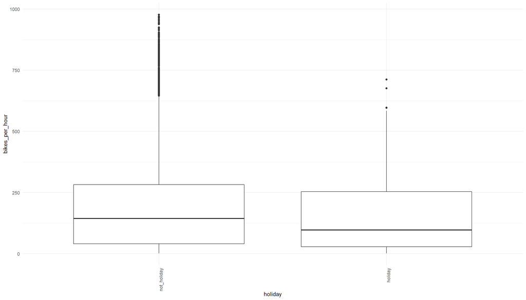

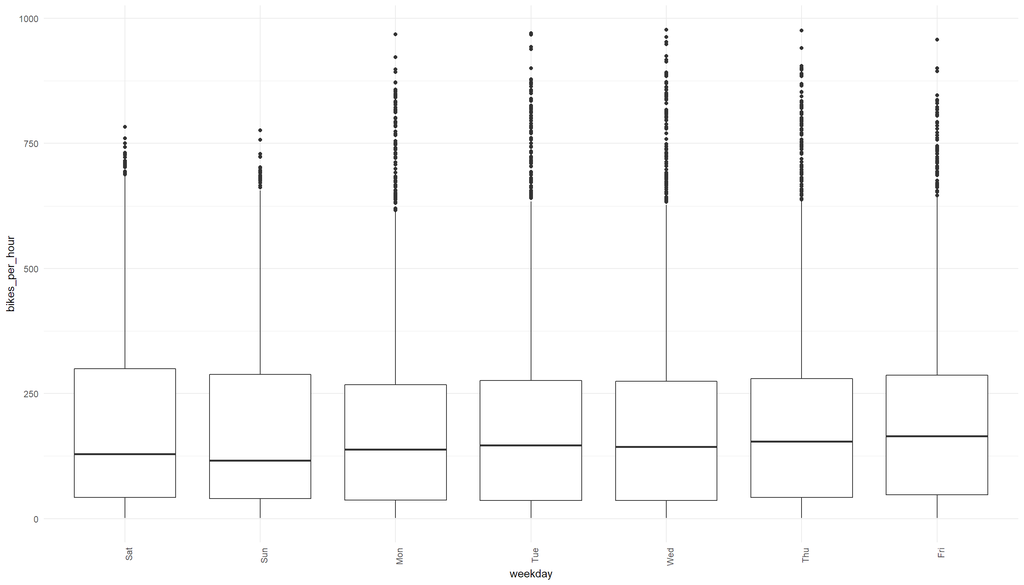

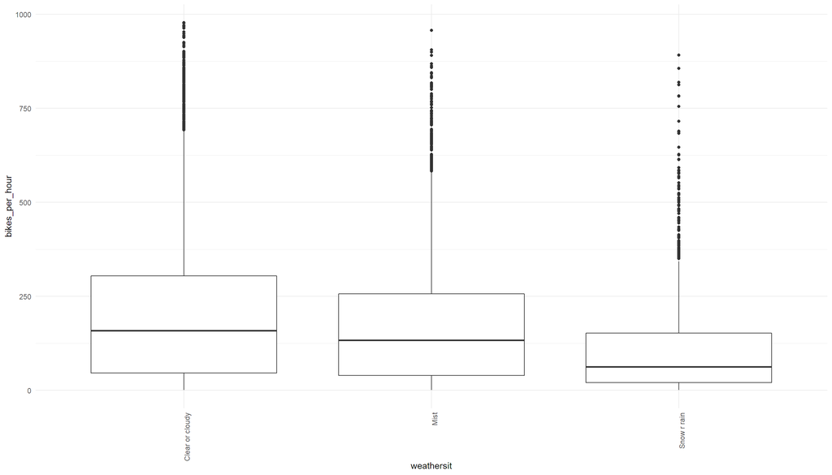

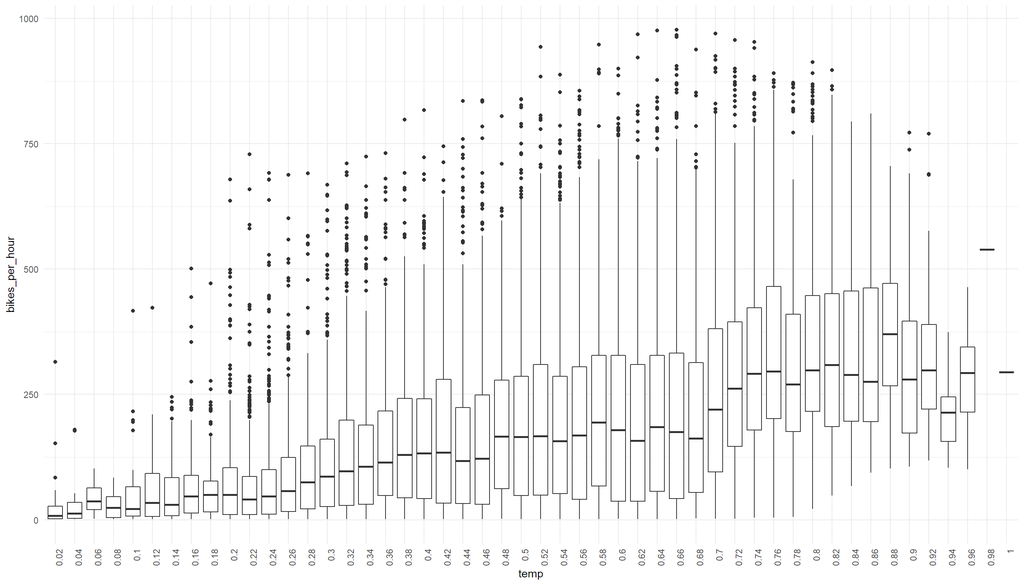

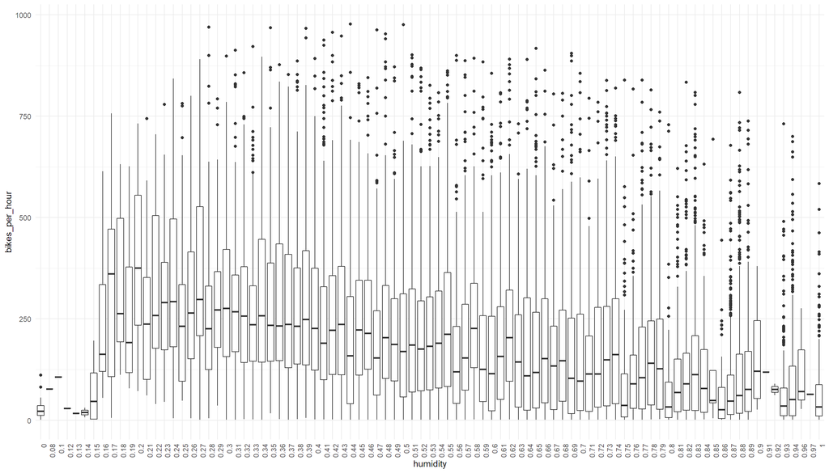

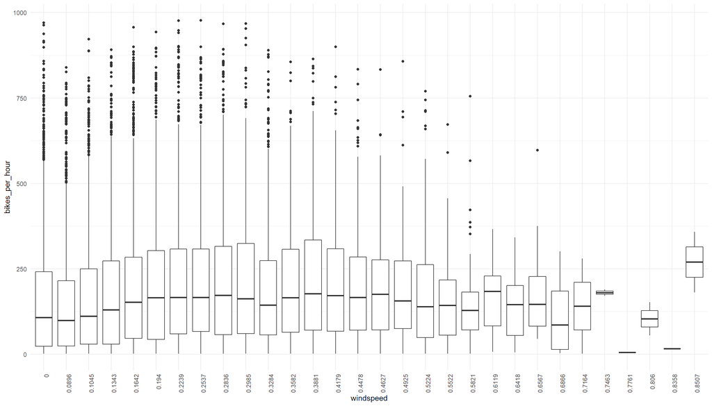

```r
# Boxplots on target variable, applying factorization to numeric variables as needed
vars <- colnames(data.all)[colnames(data.all) != "bikes_per_hour"]
for (i in vars) {
  plot <- ggplot(data.all, aes(x = as.factor(data.all[, i]), y = bikes_per_hour)) +
    geom_boxplot() +
    labs(x = i) +
    theme(axis.text.x = element_text(angle = 90, hjust = 1))
  print(plot)
}
```

```r
rm(i, vars, plot)
```

# Task 4 - Select an interaction to consider for your model.

No additional code provided. Use Task 3 code snippets to explore for interaction as appropriate.

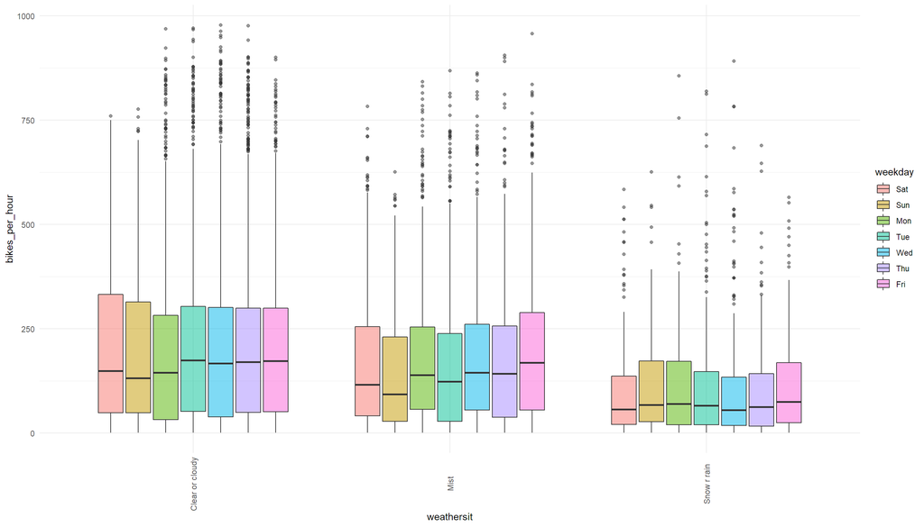

```r
# Boxplots on target variable by two factor variables
# Replace VARIABLE1 and VARIABLE2 with different factor variables. Copy and paste as needed.
ggplot(data = data.all, aes(
  x = weathersit, y = bikes_per_hour,
  fill = weekday
)) +
  geom_boxplot(alpha = 0.5) +
  theme(axis.text.x = element_text(angle = 90, vjust = 0.5))
```

```r
data.all %>%
  mutate(weekend = ifelse(weekday %in% c("Sat", "Sun"), "Weekend", "Weekday")) %>%
  group_by(weathersit, weekend) %>% summarise(median  = median(bikes_per_hour))
```

```
## # A tibble: 6 x 3
## # Groups:   weathersit [3]
##   weathersit      weekend median
##   <fct>           <chr>    <dbl>
## 1 Clear or cloudy Weekday   167
## 2 Clear or cloudy Weekend   141
## 3 Mist            Weekday   144
## 4 Mist            Weekend   102.
## 5 Snow r rain     Weekday    64
## 6 Snow r rain     Weekend    61
```

# Task 5 - Perform a k-means cluster analysis.

The following is the analysis the assistant provided. Do not change this code.

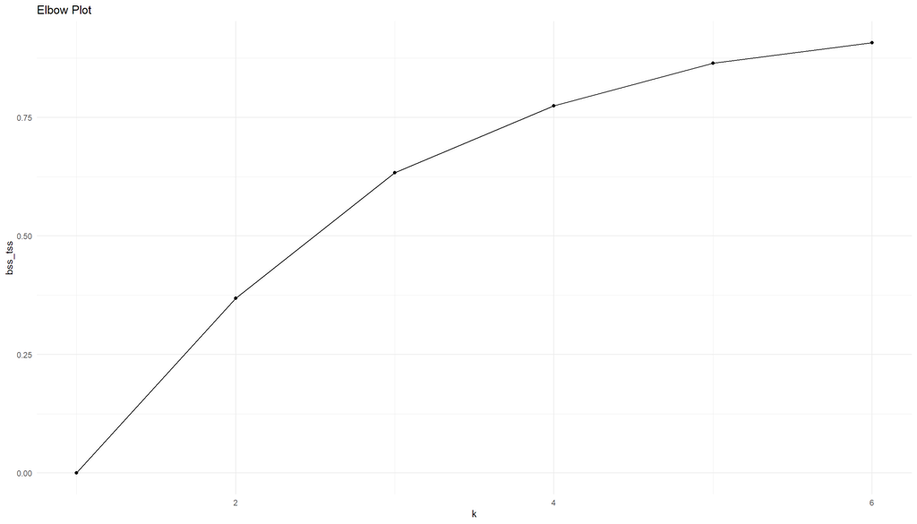

```r
# Create data.num with a subset of numeric variables for cluster analysis and scale the variables.

data.num <- data.all[, c("temp", "humidity")]
data.num$temp <- scale(data.num$temp)
data.num$humidity <- scale(data.num$humidity)

# k-means fitting and graph preparation
set.seed(200)

km1 <- kmeans(data.num, 1, nstart = 10)
data.num$group <- as.factor(km1$cluster)
p1 <- ggplot(data = data.num, aes(x = temp, y = humidity, col = group)) +
  geom_point() +
  ggtitle("k=1")

km2 <- kmeans(data.num, 2, nstart = 10)
data.num$group <- as.factor(km2$cluster)
p2 <- ggplot(data = data.num, aes(x = temp, y = humidity, col = group)) +
  geom_point() +
  ggtitle("k=2")

km3 <- kmeans(data.num, 3, nstart = 10)
data.num$group <- as.factor(km3$cluster)
p3 <- ggplot(data = data.num, aes(x = temp, y = humidity, col = group)) +
  geom_point() +
  ggtitle("k=3")

km4 <- kmeans(data.num, 4, nstart = 10)
data.num$group <- as.factor(km4$cluster)
p4 <- ggplot(data = data.num, aes(x = temp, y = humidity, col = group)) +
  geom_point() +
  ggtitle("k=4")

km5 <- kmeans(data.num, 5, nstart = 10)
data.num$group <- as.factor(km5$cluster)
p5 <- ggplot(data = data.num, aes(x = temp, y = humidity, col = group)) +
  geom_point() +
  ggtitle("k=5")

km6 <- kmeans(data.num, 6, nstart = 10)
data.num$group <- as.factor(km6$cluster)
p6 <- ggplot(data = data.num, aes(x = temp, y = humidity, col = group)) +
  geom_point() +
  ggtitle("k=6")

# k-means elbow plot
var.exp <- data.frame(
  k = c(1:6),
  bss_tss = c(
    km1$betweenss / km1$totss,
    km2$betweenss / km2$totss,
    km3$betweenss / km3$totss,
    km4$betweenss / km4$totss,
    km5$betweenss / km5$totss,
    km6$betweenss / km6$totss
  )
)
ggplot(data = var.exp, aes(x = k, y = bss_tss)) +
  geom_point() +
  geom_line() +
  ggtitle("Elbow Plot")
```

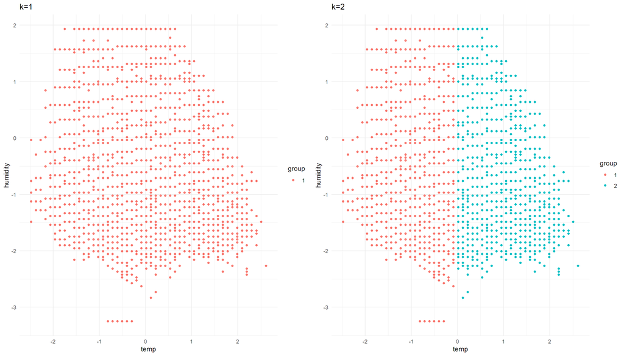

```r
rm(var.exp)

# k-means graphs
library(gridExtra)
grid.arrange(p1, p2, ncol = 2)
```

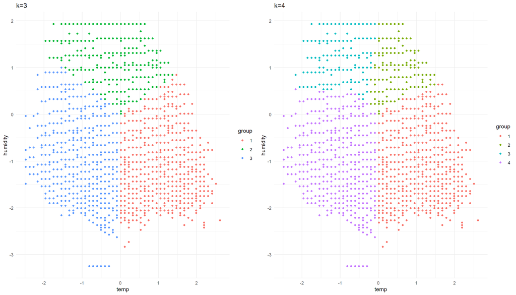

```r
grid.arrange(p3, p4, ncol = 2)
```

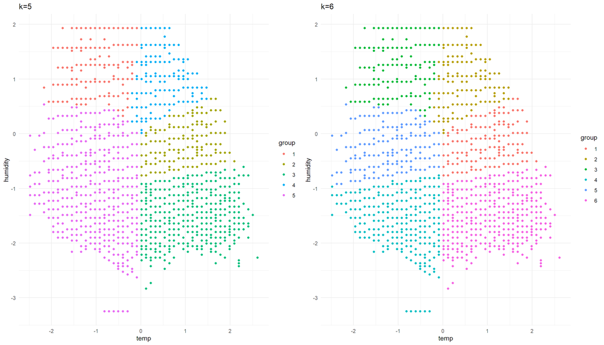

```r
grid.arrange(p5, p6, ncol = 2)
```

The following creates a cluster variable based on your selection.

```r
# Create data.clustered$cluster to house new cluster variable
data.clustered <- data.all

# Add cluster variable.
# Change km_ to one of km1, km2, km3, km4, km5, or km6 based on selected parameter k
data.clustered$cluster <- as.factor(km3$cluster)

# Remove variables used to create the cluster value
data.clustered$temp <- NULL
data.clustered$humidity <- NULL

# Remove unneeded cluster variables
rm(km1, km2, km3, km4, km5, km6)

# Summary of new variable to check work
print("Summary of new variable")
```

```
## [1] "Summary of new variable"
```

```r
summary(data.clustered$cluster)
```

```
##    1    2    3
## 5598 6085 5693
```

# Task 6 - Construct a decision tree.

Split the data into training and test data sets. Do not change the code.

```r
# Split the data into training and test data sets.
library(caret)
set.seed(1000)

# Split data.all into training and test data sets.
train_ind <- createDataPartition(data.all$bikes_per_hour, p = 0.7, list = FALSE)
data.train <- data.all[train_ind, ]
data.test <- data.all[-train_ind, ]

# split data.clustered into training and test data sets.
data.clustered.train <- data.clustered[train_ind, ]
data.clustered.test <- data.clustered[-train_ind, ]

# Compare means to validate data split
print("MEANS")
```

```
## [1] "MEANS"
```

```r
print("TRAIN")
```

```
## [1] "TRAIN"
```

```r
mean(data.train$bikes_per_hour)
```

```
## [1] 189.1589
```

```r
print("TEST")
```

```
## [1] "TEST"
```

```r
mean(data.test$bikes_per_hour)
```

```
## [1] 190.2395
```

```r
print("ALL")
```

```
## [1] "ALL"
```

```r
mean(data.all$bikes_per_hour)
```

```
## [1] 189.483
```

```r
# Remove unneeded variable
rm(train_ind)
```

Construct an unpruned regression tree. Do not change the code.

```r
# Load needed packages and set seed
library(rpart)
library(rpart.plot)
set.seed(555)

# Fit the model
tree1 <- rpart(bikes_per_hour ~ .,
  data = data.train,
  method = "anova",
  control = rpart.control(cp = 0.001, minbucket = 20)
)

# Print output for the tree
tree1
```

```
## n= 12165
##
## node), split, n, deviance, yval
##       * denotes terminal node
##
##    1) root 12165 396902000.00 189.15890
##      2) hour< 6.5 3502   5371607.00  32.36465
##        4) hour< 5.5 3006   2795364.00  25.36128
##          8) hour>=1.5 1978    651310.30  15.50961 *
##          9) hour< 1.5 1028   1582693.00  44.31712
##           18) weekday=Mon,Tue,Wed,Thu,Fri 731    344133.30  27.95212 *
##           19) weekday=Sat,Sun 297    560939.50  84.59596 *
##        5) hour>=5.5 496   1535275.00  74.80847
##         10) weekday=Sat,Sun 150     30696.19  17.92667 *
##         11) weekday=Mon,Tue,Wed,Thu,Fri 346    808844.20  99.46821 *
##      3) hour>=6.5 8663 270632100.00 252.54270
##        6) temp< 0.45 3540  61328470.00 166.95480
##         12) year=2011 1842  14691970.00 119.66020
##           24) season=1,2 1284   5710633.00  95.93069
##             48) hour>=19.5 328    364766.00  53.50305 *
##             49) hour< 19.5 956   4552857.00 110.48740 *
##           25) season=3,4 558   6594640.00 174.26340
##             50) hour>=19.5 158    334026.90 101.98100 *
##             51) hour< 19.5 400   5109026.00 202.81500
##              102) weathersit=Snow r rain 45    177604.40  85.11111 *
##              103) weathersit=Clear or cloudy,Mist 355   4228955.00 217.73520 *
##         13) year=2012 1698  38046780.00 218.26030
##           26) hour>=19.5 419   1755216.00 119.98570
##             52) hour>=21.5 214    430770.30  89.62150 *
##             53) hour< 21.5 205    921174.40 151.68290 *
##           27) hour< 19.5 1279  30919220.00 250.45500
##             54) season=1 700  10392140.00 195.61000
##              108) temp< 0.33 477   5984377.00 169.80290
##                216) weathersit=Snow r rain 58    421766.90  87.86207 *
##                217) weathersit=Clear or cloudy,Mist 419   5119274.00 181.14560
##                  434) weekday=Sat,Sun,Mon 227   1740773.00 149.14980 *
##                  435) weekday=Tue,Wed,Thu,Fri 192   2871365.00 218.97400
##                    870) hour>=8.5 140    879543.40 174.89290 *
##                    871) hour< 8.5 52    987365.80 337.65380 *
##              109) temp>=0.33 223   3410552.00 250.81170
```

[output cut: 85 more lines]

```
##                  506) weekday=Sat,Sun 50    507241.60 351.26000 *
##                  507) weekday=Mon,Tue,Wed,Thu,Fri 117   1327917.00 503.12820 *
##              127) hour< 18.5 509  18570310.00 579.26130
##                254) hour< 16.5 172   2187309.00 458.18020
##                  508) weekday=Mon,Tue,Wed,Thu 99    638170.20 410.09090 *
##                  509) weekday=Sat,Sun,Fri 73   1009705.00 523.39730 *
##                255) hour>=16.5 337  12574370.00 641.05930
##                  510) weekday=Sat,Sun 103   1802301.00 455.85440
##                   1020) humidity>=0.58 30    617591.00 355.96670 *
##                   1021) humidity< 0.58 73    762372.30 496.90410 *
##                  511) weekday=Mon,Tue,Wed,Thu,Fri 234   5683955.00 722.58120
##                   1022) humidity>=0.685 31   1523276.00 590.58060 *
##                   1023) humidity< 0.685 203   3538045.00 742.73890
##                     2046) temp< 0.57 44    932072.60 649.40910 *
##                     2047) temp>=0.57 159   2116653.00 768.56600 *
```

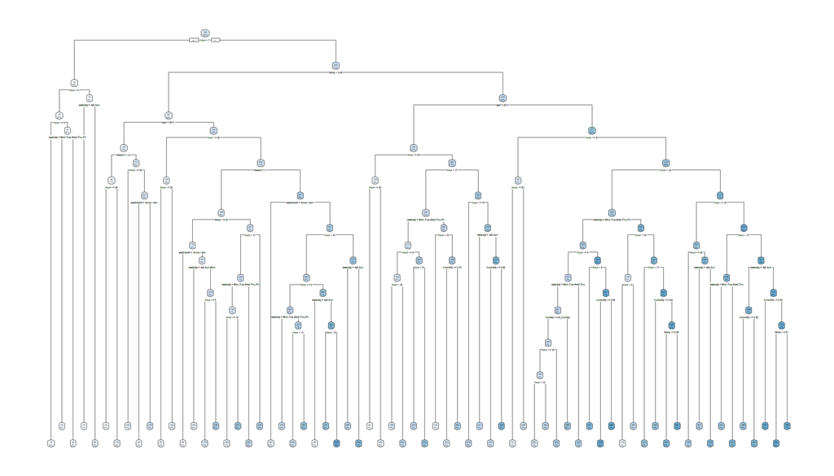

```r
# Plot the tree
rpart.plot(tree1, tweak = 0.8)
```

Display the complexity parameter table and plot.

```r
# Display the complexity parameter table and plot for tree1.
tree1$cptable
```

```
##             CP nsplit rel error    xerror        xstd
## 1  0.304604914      0 1.0000000 1.0001128 0.016610474
## 2  0.110481143      1 0.6953951 0.6954729 0.013217062
## 3  0.057776682      2 0.5849139 0.5876316 0.011393520
## 4  0.042345685      3 0.5271373 0.5313812 0.009787735
## 5  0.032256585      4 0.4847916 0.4893667 0.009046308
## 6  0.021641928      5 0.4525350 0.4567516 0.008408229
## 7  0.019123090      6 0.4308931 0.4337247 0.007777176
## 8  0.015740087      9 0.3735238 0.3926889 0.007377010
## 9  0.014622390     10 0.3577837 0.3769229 0.007015976
## 10 0.013535698     12 0.3285389 0.3454336 0.006502200
## 11 0.011718755     13 0.3150032 0.3224721 0.006059356
## 12 0.011207730     14 0.3032845 0.3110335 0.005723493
## 13 0.007945383     16 0.2808690 0.2889720 0.005470236
## 14 0.007569949     19 0.2570329 0.2713240 0.005375667
```

[output cut: 40 more lines]

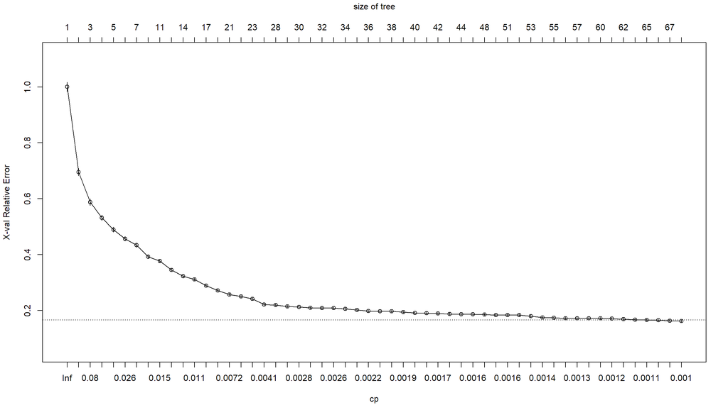

```r
plotcp(tree1)
```

Prune the tree as instructed and display it.

```r
# Prune the tree using the complexity parameter that will result in four leaves.
# Replace xx with an appropriate value
tree2 <- prune(tree1, cp = 0.042345685)

# Print a summary of the tree
tree2
```

```
## n= 12165
##
## node), split, n, deviance, yval
##       * denotes terminal node
##
##  1) root 12165 396902000 189.15890
##    2) hour< 6.5 3502   5371607  32.36465 *
##    3) hour>=6.5 8663 270632100 252.54270
##      6) temp< 0.45 3540  61328470 166.95480 *
##      7) temp>=0.45 5123 165453400 311.68400
##       14) year=2011 2505  42321230 243.28700 *
##       15) year=2012 2618 100200500 377.12870 *
```

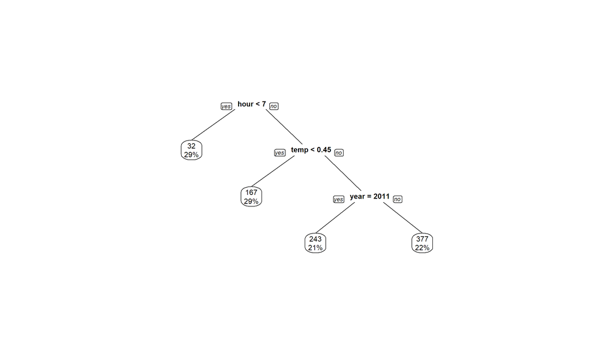

```r
# Plot the tree
prp(tree2,
  yesno = 2,
  extra = 100
)
```

# Task 7 - Construct a boosted decision tree.

Construct a boosted tree with given parameters and shrinkage of 0.01. Do not change the code.

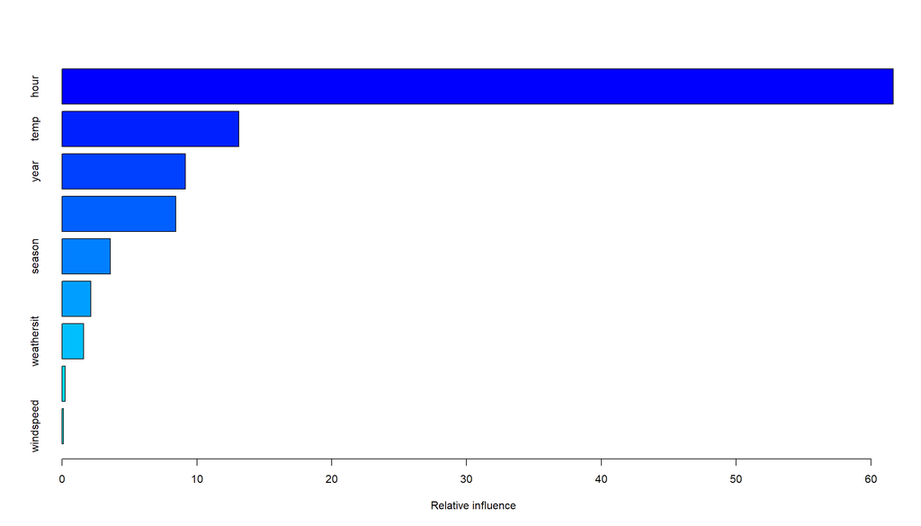

```
##                   var     rel.inf
## hour             hour 61.66091751
## temp             temp 13.11384443
## year             year  9.15818289
## weekday       weekday  8.43967371
## season         season  3.59089650
## humidity     humidity  2.13473744
## weathersit weathersit  1.59521522
## holiday       holiday  0.21667555
## windspeed   windspeed  0.08985675
```

```r
# Fit boosted tree
library(gbm)
boost.tree1 <- gbm(bikes_per_hour ~ .,
  data = data.train,
  distribution = "gaussian",
  n.trees = 1000,
  shrinkage = 0.01,
  interaction.depth = 4
) # number of total splits in each tree
summary(boost.tree1)
```

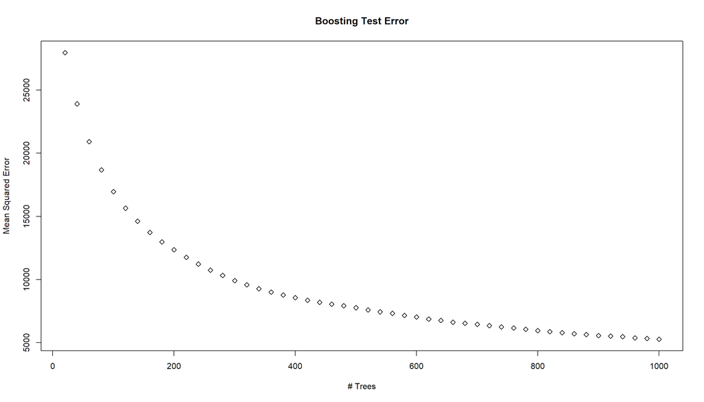

```r
# Make predictions from boosted decision tree using a number of fitted trees ranging from 20 to 1000
n.trees <- seq(from = 20, to = 1000, by = 20)
predbytrees <- predict(boost.tree1, newdata = data.test, n.trees = n.trees)

# Plot the MSE for each decision tree
boost.err <- with(data.test, apply((predbytrees - bikes_per_hour)^2, 2, mean))
plot(n.trees, boost.err, pch = 23, ylab = "Mean Squared Error", xlab = "# Trees", main = "Boosting Test Error")
```

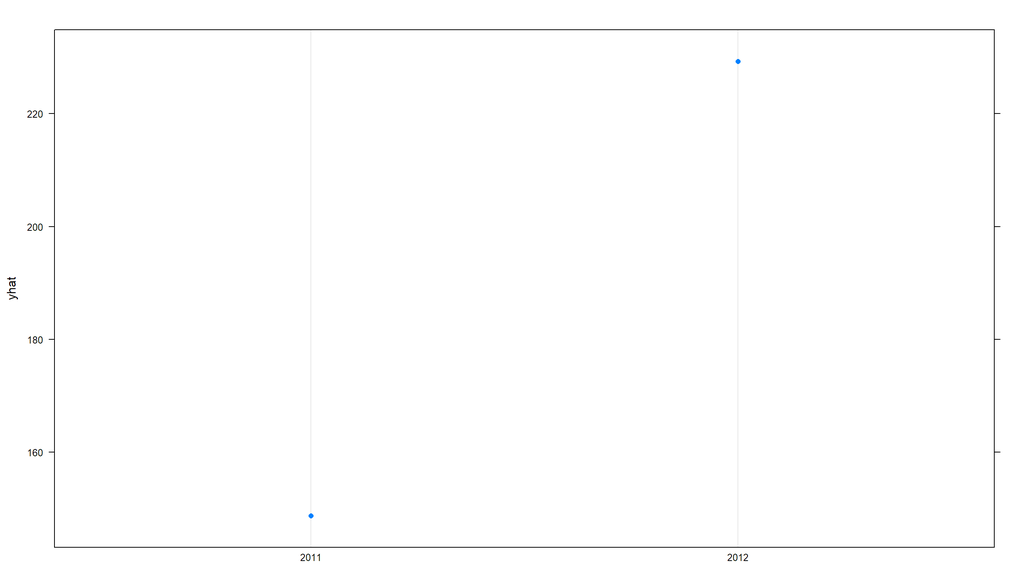

```r
# Plot partial dependence plots on a variable
# Replace VARIABLE with the desired variable. Copy and paste as needed.
library(pdp)
partial(boost.tree1, n.trees = 1000, pred.var = "year", plot = TRUE)
```